# Analysis Script - Activation of basic-level categories in the human brain based on different cue types.

Group35

29 7 2020

# Data Wrangling

```r
# importing data from our _magpie experiment
data <- read_csv("main_data.csv")
```

```r
# creating data frame that we are going to work with in our analysis
data_agg <- data %>%
  # filtering for all matching, main trials in which the subjects gave correct answers
  filter(trial_name == "main", correctness == 'correct', match == 'match') %>%
  # selecting the columns that are needed for analysis
  select(submission_id, RT, sound_type, congruency, sound_instance, image_category, image_instance, number_of_image) %>%
  # renaming columns for simplicity
  rename('cue_type' = sound_type, "subject_id" = submission_id, "category" = image_category) %>%
  # substracting 2250ms from each RT measurement (the time that goes by before the participants can give their answer).
  # detailed reasoning for this can be found in our preregistration
  mutate(RT = RT-2250) %>%
  # filtering out outliers
  filter(RT<1500 & RT>250)

# taking a look at the new data frame
head(data_agg)
```

```
## # A tibble: 6 x 8
##   subject_id    RT cue_type congruency sound_instance category image_instance
##        <dbl> <dbl> <chr>    <chr>      <chr>          <chr>    <chr>
## 1       1649  1005 sound    congruent  seagull        bird     seagull
## 2       1649   720 label    -          female         instrum~ violin
## 3       1649   556 label    -          female         dog      chihuahua
## 4       1649   609 label    -          female         car      v8
## 5       1649  1052 sound    congruent  ford           car      ford
## 6       1649   720 sound    incongrue~ chihuahua      dog      rottweiler
## # ... with 1 more variable: number_of_image <dbl>
```

## Max and Mean Error Rate

```r
# checking if a subject just guessed/did not understand the task
data_error <- data %>%
  filter(correctness == 'incorrect') %>%
  group_by(submission_id, correctness) %>%
  count()

# max error rate of all participants is 8% -> no one just guessed to complete the experiment
max(data_error$n)/150
```

```
## [1] 0.08
```

```r
print(mean(data_error$n)/150, digits = 4)
```

```
## [1] 0.04
```

Judging by the maximum and mean error rate of all participants we see that everyone performed very accurately (Mean = 96%) and no one was guessing randomly.

## Percentage of Outliers

```r
# data set inluding all outliers
filtered_with_outliers <- data %>% filter(trial_name == "main", correctness == 'correct', match == 'match') %>% count()

# data set without the outliers
filtered_without_outliers <- length(data_agg$RT)

# Percentage of outliers in our filtered () data set
outlier_proportion <- 1-filtered_without_outliers/filtered_with_outliers
outlier_proportion
```

```
##            n
## 1 0.06462442
```

After filtering the data for main, correct and matching trials, reaction times (RTs) shorter than 250 ms. or longer than 1500 ms. were removed (154 trials removed, 6,46% of total).

## Log transformation of RT

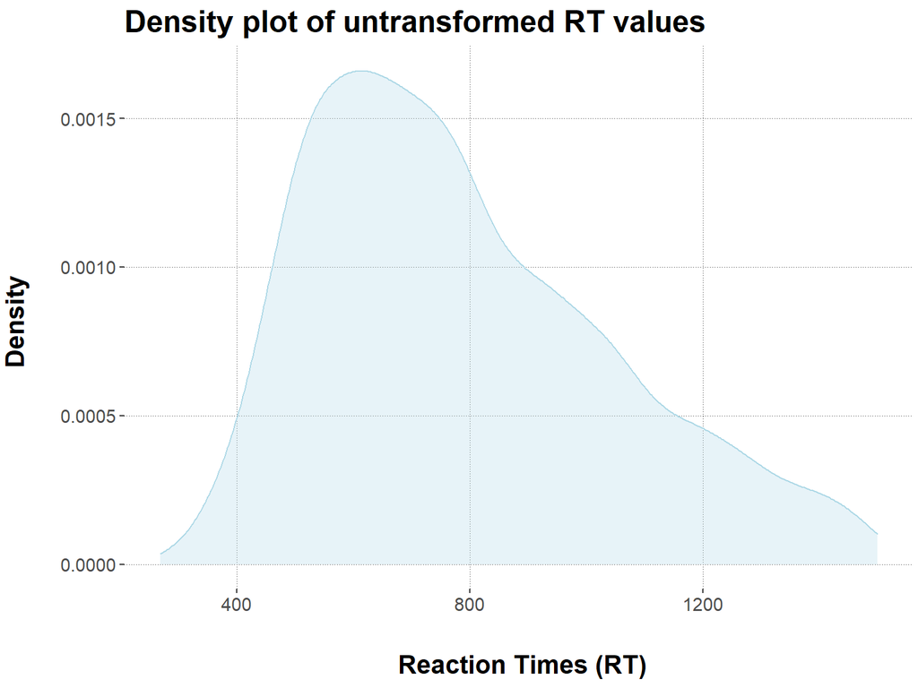

```r
# log transform RT
data_agg$RT_log <- log(data_agg$RT)

# plot the regular RT values as a density
data_agg %>%
  ggplot() +
  geom_density(aes(x = RT), color = "lightblue", fill = "lightblue", alpha = 0.3) +
  labs(
    title = "Density plot of untransformed RT values",
    y = "Density \n",
    x = "\n Reaction Times (RT)"
  )
```

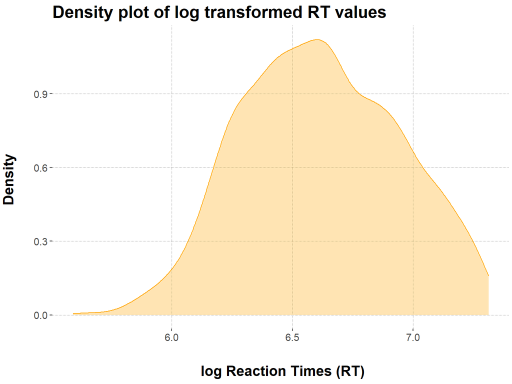

```r
# plot the log transformed RT
data_agg %>%
  ggplot() +
  geom_density(aes(x = RT_log), color = "orange", fill = "orange", alpha = 0.3) +
  labs(
    title = "Density plot of log transformed RT values",
    y = "Density \n",
    x = "\n log Reaction Times (RT)"
  )
```

After having log-transformed the reaction time values (RT) the data looks indeed more normally distributed.

## Checking for major differnces in RT between categories

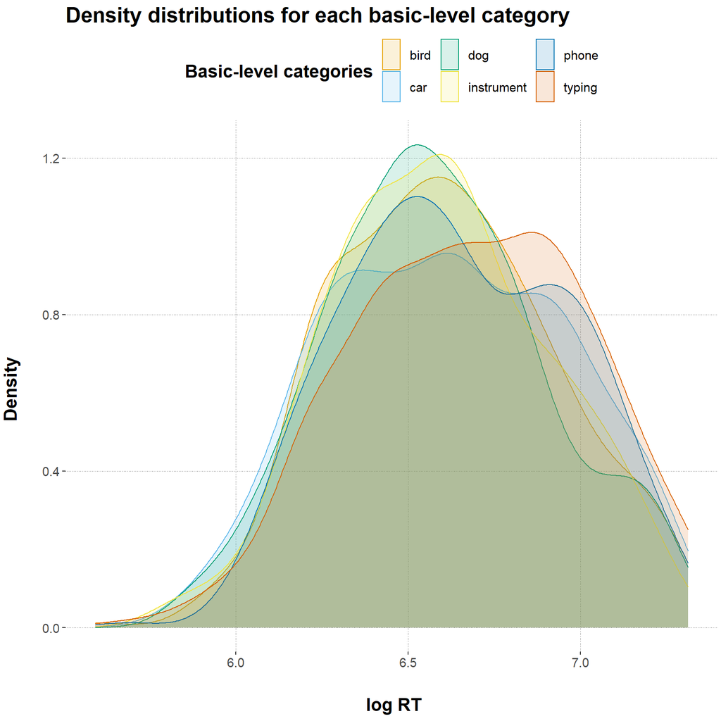

```r
# checking if any category exhibits unusual RTs
data_agg %>%
  ggplot() +
  geom_density(aes(x = RT_log, color = category, fill = category ), alpha = 0.15) +
  labs(
    title = "Density distributions for each basic-level category",
    y = "Density \n",
    x = "\n log RT",
    fill = "Basic-level categories",
    color = "Basic-level categories")
```

All categories exhibit roughly the same distribution of reaction time values with only minor deviations. To account for those deviations we will include random effects.

## Data sets for each hypothesis

```r
# creating data set for our first hypothesis
data_hypothesis1 <- data_agg %>%
  #filter(image_category != "dog") %>%
  # calculating the mean RT for each cue type (label, sound), to get a first intuition of the differences it RT
  group_by(cue_type) %>%
  mutate(RT_mean = mean(RT_log))

# creating data set for our second hypothesis
data_hypothesis2 <- data_agg %>%
   # calculating the mean RT for congruent and incongruent trials, to get a first intuition of the differences it RT
  filter(cue_type == 'sound') %>%
  group_by(congruency) %>%
  mutate(RT_mean = mean(RT_log))

# creating data set for our third hypothesis
data_hypothesis3 <- data_agg %>%
  # calculating the mean RT for congruent and incongruent trials, to get a first intuition of the differences it RT
  filter(congruency != "incongruent") %>%
  group_by(cue_type) %>%
  mutate(RT_mean = mean(RT_log))


# creating data set for our fourth hypothesis
data_agg2 <- data %>%
  # filtering for all mismatching, main trials in which the subjects gave correct answers
  filter(trial_name == "main", correctness == 'correct', match == 'mismatch') %>%
  # selecting the columns that are needed for analysis
  select(submission_id, RT, sound_type, congruency, sound_instance, image_category, image_instance, number_of_image) %>%
  # renaming columns for simplicity
  rename('cue_type' = sound_type, "subject_id" = submission_id, "category" = image_category) %>%
  # substracting 2250ms from each RT measurement (the time that goes by before the participants can give their answer).
  # detailed reasoning for this can be found in our preregistration
  mutate(RT = RT-2250) %>%
  # filtering out outliers
  filter(RT<1500 & RT>250)

data_agg2$RT_log <- log(data_agg2$RT)


data_hypothesis4 <- data_agg2 %>%
  # calculating the mean RT for congruent and incongruent trials, to get a first intuition of the differences it RT
  group_by(cue_type) %>%
  mutate(RT_mean = mean(RT_log))
```

# Hypothesis-driven plots

## Plot for first Hypothesis

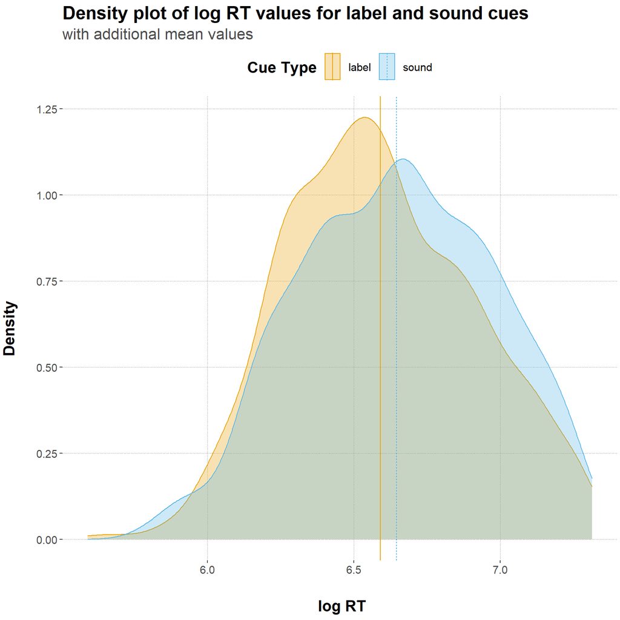

```r
# creating data set for our first hypothesis
data_hypothesis1 <- data_agg %>%
  #filter(image_category != "dog") %>%
  # calculating the mean RT for each cue type (label, sound), to get a first intuition of the differences it RT
  group_by(cue_type) %>%
  mutate(RT_mean = mean(RT_log))

# Density plot for both cue types
data_hypothesis1 %>%
  ggplot() +
  # adding the density plots and color accordingly
  geom_density(aes(x = RT_log, color = cue_type, fill = cue_type), alpha = 0.3) +
  # adding the vertical lines for each condition´s mean reaction time value
  # for better distinguishability add for each condition a different color
  geom_vline(aes(xintercept = RT_mean, color = cue_type, linetype = cue_type)) +
  # adding infos to the plot
  labs( title = "Density plot of log RT values for label and sound cues",
        subtitle = "with additional mean values",
        x = "\n log RT",
        y = "Density\n",
        fill = "Cue Type",
        color = "Cue Type",
        linetype = "Cue Type"
       )
```

The densitiy distribution of reaction time values for the sound cue are slightly shifted to the right compared to the distribution of RT’s for the label cue. This can also be seen in their respective mean reaction time, giving a positive first insight for our first hypothesis.

## Plot for second Hypothesis

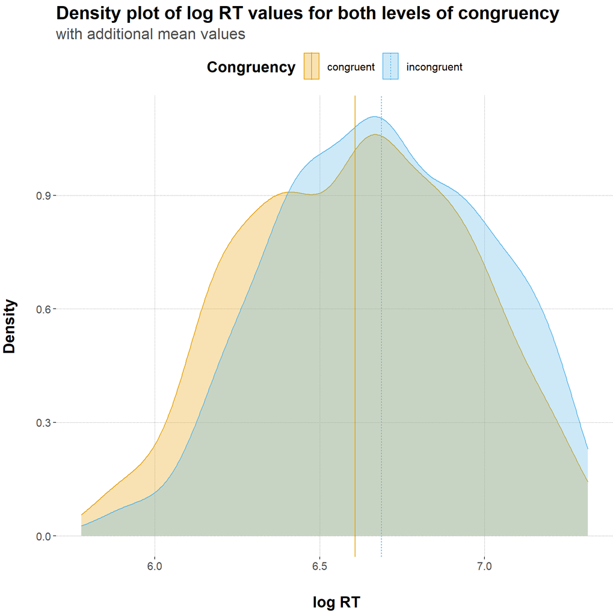

```r
# creating data set for our second hypothesis
data_hypothesis2 <- data_agg %>%
   # calculating the mean RT for congruent and incongruent trials, to get a first intuition of the differences it RT
  filter(cue_type == 'sound') %>%
  group_by(congruency) %>%
  mutate(RT_mean = mean(RT_log))

# Density plot for both cue types
data_hypothesis2 %>%
  ggplot() +
  # adding the density plots and color accordingly
  geom_density(aes(x = RT_log, color = congruency, fill = congruency), alpha = 0.3) +
  # adding the vertical lines for each condition´s mean reaction time value
  # for better distinguishability add different colors
  geom_vline(aes(xintercept = RT_mean, color = congruency, linetype = congruency)) +
  # adding infos to the plot
  labs(title = "Density plot of log RT values for both levels of congruency",
       subtitle = "with additional mean values",
       x = "\n log RT",
       y = "Density\n",
       fill = "Congruency",
       color = "Congruency",
       linetype = "Congruency"
       )
```

The densitiy distribution of reaction time values for the incongruent trials are slightly shifted to the right compared to the distribution of RT’s for the congruent ones. This can also be seen in their respective mean reaction time, giving a positive first insight for our second hypothesis.

## Plot for third Hypothesis

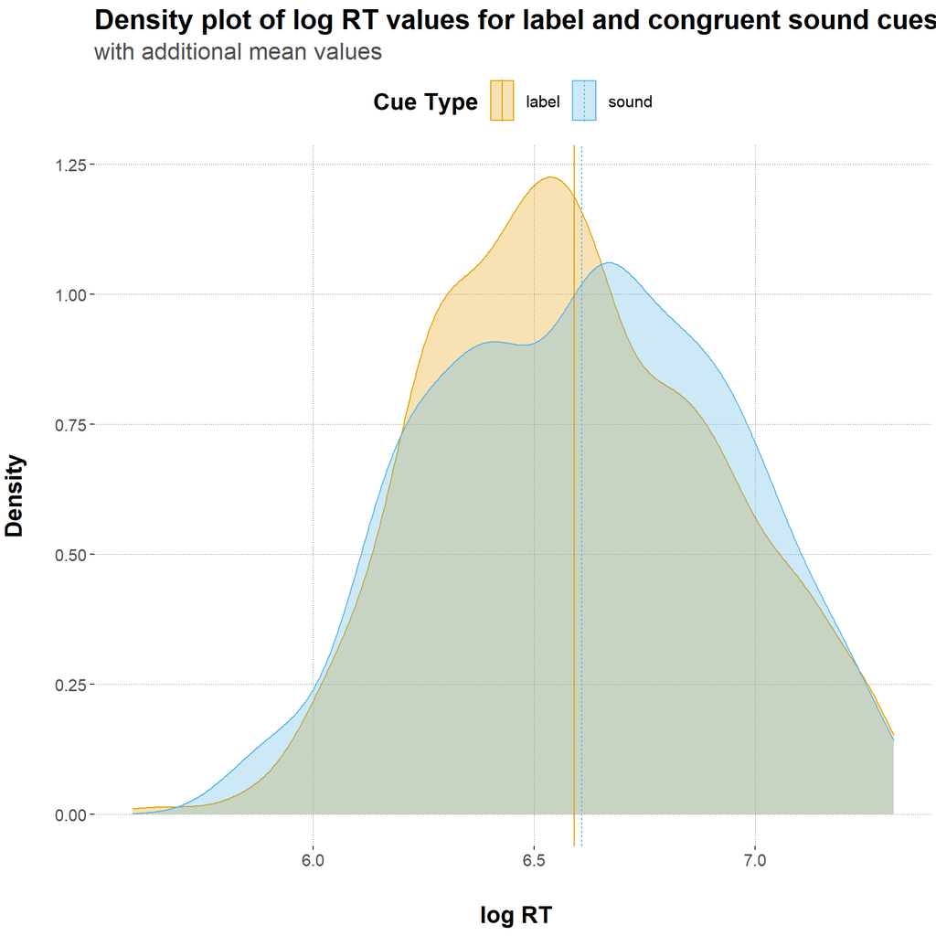

```r
# creating data set for our first hypothesis
data_hypothesis3 <- data_agg %>%
  filter(congruency != "incongruent") %>%
  group_by(cue_type) %>%
  mutate(RT_mean = mean(RT_log))

# Density plot for both cue types
data_hypothesis3 %>%
  ggplot() +
  # adding the density plots and color accordingly
  geom_density(aes(x = RT_log, color = cue_type, fill = cue_type), alpha = 0.3) +
  # adding the vertical lines for each condition´s mean reaction time value
  # for better distinguishability add for each condition a different color
  geom_vline(aes(xintercept = RT_mean, color = cue_type, linetype = cue_type)) +
  # adding infos to the plot
  labs(title = "Density plot of log RT values for label and congruent sound cues",
       subtitle = "with additional mean values",
        x = "\n log RT",
        y = "Density\n",
        fill = "Cue Type",
        color = "Cue Type",
        linetype = "Cue Type"
       )
```

Here the mean reaction times are very close together and the densitiy distributions do not differ much. No clear trend is visible. Hence, our data does not provide much evidence (at least visually) in favor of our third hypothesis.

## Plot for fourth Hypothesis

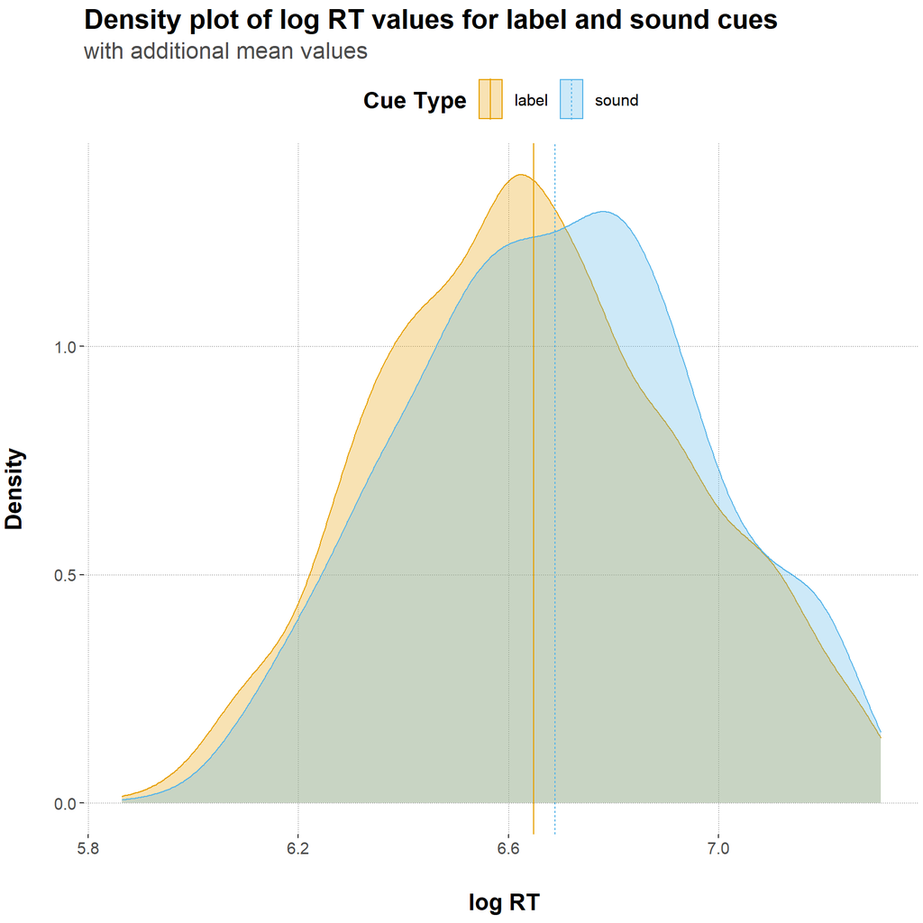

```r
# Density plot for both cue types
data_hypothesis4 %>%
  ggplot() +
  # adding the density plots and color accordingly
  geom_density(aes(x = RT_log, color = cue_type, fill = cue_type), alpha = 0.3) +
  # adding the vertical lines for each condition´s mean reaction time value
  # for better distinguishability add for each condition a different color
  geom_vline(aes(xintercept = RT_mean, color = cue_type, linetype = cue_type)) +
  # adding infos to the plot
  labs( title = "Density plot of log RT values for label and sound cues",
        subtitle = "with additional mean values",
        x = "\n log RT",
        y = "Density\n",
        fill = "Cue Type",
        color = "Cue Type",
        linetype = "Cue Type"
       )
```

When looking at the densities of reaction time values for both cue types, but only considering mismatching trials, we see similar results as in the first plot. Hence, the data lends visual credence to our fourth hypothesis.

# Running brm models for hypothesis

We performed our statistical analysis using R as well as RStudio and based our inference on mixed effects bayesian linear regression modelling using the R package `brms`. For each model we specified maximal random effects that were liscenced by the data. In case the CrI’s of the respective random effect included 0, we excluded the RE and compared the resulting model to the previous one via Leave-one-out cross validation (using the `LOO` package). For comparision we always included the model without the random effects structure. Out of all models we then chose the one with the highest ELPD score to perform the hypothesis testing. For visualization and data wrangling purposes we made use of the R packages `tidyverse`, `tidybayes`, `bayesplot` and `HDInterval`.

## First hypothesis

```r
# checking if random effects (intercept and slope) are in theory possible to apply to our second model
xtabs(~cue_type+subject_id, data_hypothesis1)
```

```
##         subject_id
## cue_type 1421 1422 1423 1425 1427 1430 1431 1432 1433 1434 1436 1468 1476 1478
##    label   29   32   33   28   35   35   34   35   35   35   32   36   34   36
##    sound   19   26   33   28   34   35   32   33   32   34   31   28   30   34
##         subject_id
## cue_type 1479 1482 1483 1484 1486 1494 1495 1505 1515 1536 1562 1571 1573 1575
##    label   34   33   36   33   36   33   35   34   35   34   34   30   34   34
##    sound   31   31   31   35   28   33   33   30   32   26   33   27   30   31
##         subject_id
## cue_type 1583 1603 1612 1630 1636 1639 1649
##    label   29   32   33   34   33   30   33
##    sound   29   15   30   30   36   27   34
```

```r
xtabs(~cue_type+category, data_hypothesis1)
```

```
##         category
## cue_type bird car dog instrument phone typing
##    label  193 196 204        199   194    182
##    sound  185 150 191        187   172    176
```

Each subject and each category provides multiple data points for each level of cue type. Hence, it is in theory justified to use random by subjects / by category intercepts and slopes.

We will run several brm models for the first hypothesis, so that we can compare their performance later on.

```r
# brm model without random effects
hypo1 <- brm(
  RT_log ~ cue_type,
  # data
  data = data_hypothesis1,
  # seed
  seed = 1
)
```

```r
# brm model with random effects that are licensed by the data
# as 0 was included in the random by category slope in the max_re model we just used the random by category intercept here
hypo1_re <- brm(
  RT_log ~ cue_type + (cue_type || subject_id) + (1 || category),
  # data
  data = data_hypothesis1,
  # seed
  seed = 1,
  # increase adapt delta to 0.9 since we encountered 5 divergent iterations
  control = list(adapt_delta = 0.9)
)
```

```r
# brm model with maximal random effects that are licensed by the data
hypo1_max_re <- brm(
  RT_log ~ cue_type + (cue_type || subject_id) + (cue_type || category),
  # data
  data = data_hypothesis1,
  # seed
  seed = 1
)
```

### Model output and fit

```r
# checking the models output and fit
hypo1
```

```
##  Family: gaussian
##   Links: mu = identity; sigma = identity
## Formula: RT_log ~ cue_type
##    Data: data_hypothesis1 (Number of observations: 2229)
## Samples: 4 chains, each with iter = 2000; warmup = 1000; thin = 1;
##          total post-warmup samples = 4000
##
## Population-Level Effects:
##               Estimate Est.Error l-95% CI u-95% CI Rhat Bulk_ESS Tail_ESS
## Intercept         6.59      0.01     6.57     6.61 1.00     4998     2825
## cue_typesound     0.05      0.01     0.03     0.08 1.00     4204     3254
##
## Family Specific Parameters:
##       Estimate Est.Error l-95% CI u-95% CI Rhat Bulk_ESS Tail_ESS
## sigma     0.32      0.00     0.31     0.33 1.00     4422     3038
##
## Samples were drawn using sampling(NUTS). For each parameter, Bulk_ESS
## and Tail_ESS are effective sample size measures, and Rhat is the potential
## scale reduction factor on split chains (at convergence, Rhat = 1).
```

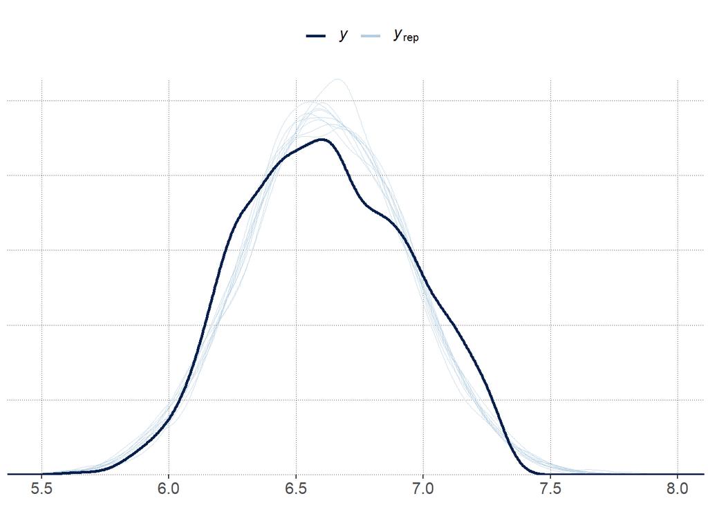

```r
pp_check(hypo1)
```

```r
# checking the models output and fit
hypo1_re
```

```
##  Family: gaussian
##   Links: mu = identity; sigma = identity
## Formula: RT_log ~ cue_type + (cue_type || subject_id) + (1 || category)
##    Data: data_hypothesis1 (Number of observations: 2229)
## Samples: 4 chains, each with iter = 2000; warmup = 1000; thin = 1;
##          total post-warmup samples = 4000
##
## Group-Level Effects:
## ~category (Number of levels: 6)
##               Estimate Est.Error l-95% CI u-95% CI Rhat Bulk_ESS Tail_ESS
## sd(Intercept)     0.05      0.03     0.02     0.12 1.01     1218     1826
##
## ~subject_id (Number of levels: 35)
##                   Estimate Est.Error l-95% CI u-95% CI Rhat Bulk_ESS Tail_ESS
## sd(Intercept)         0.15      0.02     0.12     0.20 1.01     1038     1497
## sd(cue_typesound)     0.07      0.02     0.04     0.11 1.00     1144     1417
##
## Population-Level Effects:
##               Estimate Est.Error l-95% CI u-95% CI Rhat Bulk_ESS Tail_ESS
## Intercept         6.60      0.04     6.53     6.67 1.00      847     1637
## cue_typesound     0.06      0.02     0.02     0.09 1.00     2596     3065
##
## Family Specific Parameters:
##       Estimate Est.Error l-95% CI u-95% CI Rhat Bulk_ESS Tail_ESS
## sigma     0.29      0.00     0.28     0.30 1.00     6179     2950
##
## Samples were drawn using sampling(NUTS). For each parameter, Bulk_ESS
## and Tail_ESS are effective sample size measures, and Rhat is the potential
## scale reduction factor on split chains (at convergence, Rhat = 1).
```

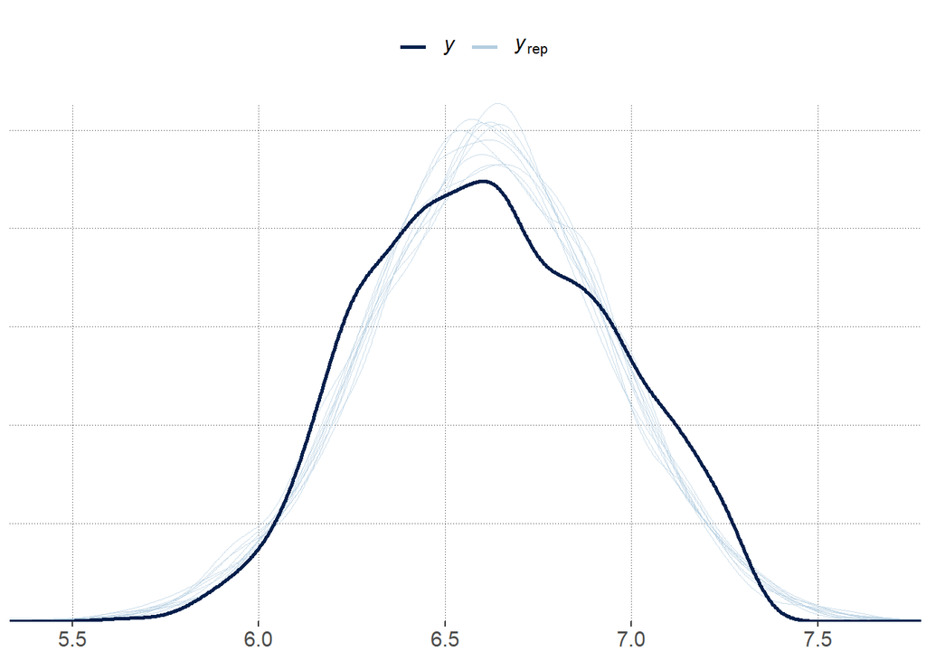

```r
pp_check(hypo1_re)
```

```r
# checking the models output and fit
hypo1_max_re
```

```
##  Family: gaussian
##   Links: mu = identity; sigma = identity
## Formula: RT_log ~ cue_type + (cue_type || subject_id) + (cue_type || category)
##    Data: data_hypothesis1 (Number of observations: 2229)
## Samples: 4 chains, each with iter = 2000; warmup = 1000; thin = 1;
##          total post-warmup samples = 4000
##
## Group-Level Effects:
## ~category (Number of levels: 6)
##                   Estimate Est.Error l-95% CI u-95% CI Rhat Bulk_ESS Tail_ESS
## sd(Intercept)         0.05      0.03     0.01     0.12 1.00      981      736
## sd(cue_typesound)     0.04      0.03     0.00     0.10 1.00     1196     1335
##
## ~subject_id (Number of levels: 35)
##                   Estimate Est.Error l-95% CI u-95% CI Rhat Bulk_ESS Tail_ESS
## sd(Intercept)         0.15      0.02     0.12     0.20 1.01      874     1840
## sd(cue_typesound)     0.07      0.02     0.04     0.11 1.00     1201     1227
##
## Population-Level Effects:
##               Estimate Est.Error l-95% CI u-95% CI Rhat Bulk_ESS Tail_ESS
## Intercept         6.60      0.04     6.53     6.67 1.00      843      810
## cue_typesound     0.06      0.02     0.01     0.11 1.00     2077     2114
##
## Family Specific Parameters:
##       Estimate Est.Error l-95% CI u-95% CI Rhat Bulk_ESS Tail_ESS
## sigma     0.29      0.00     0.28     0.30 1.00     6327     2745
##
## Samples were drawn using sampling(NUTS). For each parameter, Bulk_ESS
## and Tail_ESS are effective sample size measures, and Rhat is the potential
## scale reduction factor on split chains (at convergence, Rhat = 1).
```

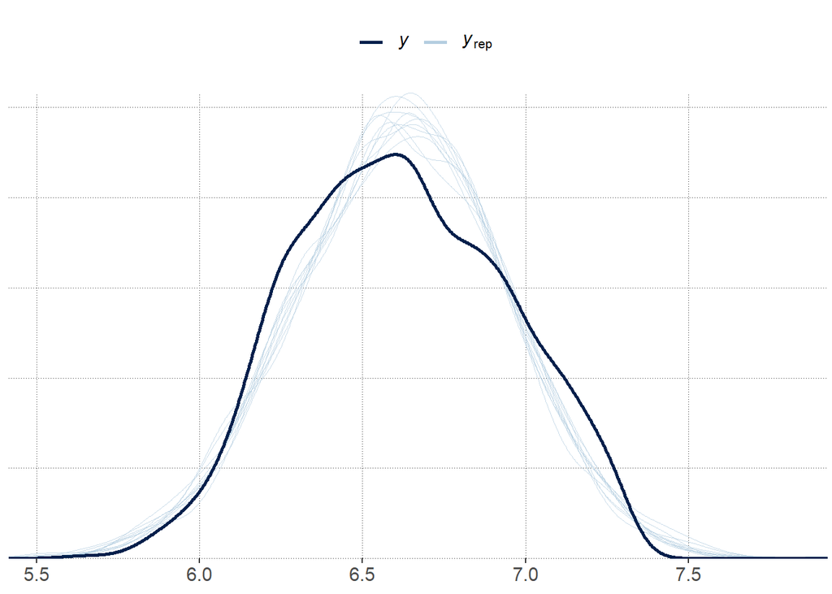

```r
pp_check(hypo1_max_re)
```

### Model comparison

```r
#Comparing both models using loo compare
model1 <- loo(hypo1)
model1_re <- loo(hypo1_re)
model1_max_re <- loo(hypo1_max_re)
loo_comp1 <- loo_compare(list(model1 = model1, model1_re = model1_re, model1_max_re = model1_max_re))
loo_comp1
```

```
##               elpd_diff se_diff
## model1_re        0.0       0.0
## model1_max_re   -0.3       1.4
## model1        -233.6      21.9
```

```r
#Using the z-test to obtain the p-value such we can judge significance of the loo compare results
1-pnorm(-loo_comp1[2,1], loo_comp1[2,2])
```

```
## [1] 0.8632966
```

```r
1-pnorm(-loo_comp1[3,1], loo_comp1[3,2])
```

```
## [1] 0
```

#### Evaluation of all models

All our model converged and had no problems with divergent iterations. When comparing the posterior (based on samples from the model) against the data via `pp_check()` our models performed fairly well. The resulting $Y_{rep}'s$ seem to be able to describe the underlying data distribution $y$. This indicates (at least visuallly) that our models are appropriate for describing the data at hand and do not lack any importaat aspects of the original data. Looking at the credible intervals for the specified RE’s, they all exclude the 0 apart from the random by category slope for cue_type, making the parameters credibly bigger than zero. This means that the data at hand lends credence to these factors (where 0 is excluded in CrI) playing a role in the data-generating process. Using the `loo_compare()` function we found that the **max_re** and **re** model performed significantly better than the model without random effects by by ca. 234 points of expected log predictive density. While the difference between the **max_re** and **re** model was non significant we still chose the one with the highest overall ELPD score (here: model1_re).

```r
# in order to make our results intuitively understandable we retransformed our slope parameter back to ms
hypo1_re %>%
  spread_draws(b_cue_typesound, b_Intercept) %>%
  select(b_cue_typesound, b_Intercept) %>%
  mutate(slope = exp(b_Intercept+b_cue_typesound)-exp(b_Intercept)) %>%
  select(slope) %>%
  gather(key = "parameter", value = "posterior") %>%
  group_by(parameter) %>%
  summarise(mean_posterior = mean(posterior),
            `95lowerCrI` = HDInterval::hdi(posterior, credMass = 0.95)[1],
            `95higherCrI` = HDInterval::hdi(posterior, credMass = 0.95)[2])
```

```
## # A tibble: 1 x 4
##   parameter mean_posterior `95lowerCrI` `95higherCrI`
##   <chr>              <dbl>        <dbl>         <dbl>
## 1 slope               43.8         17.7          71.6
```

### Visual analysis

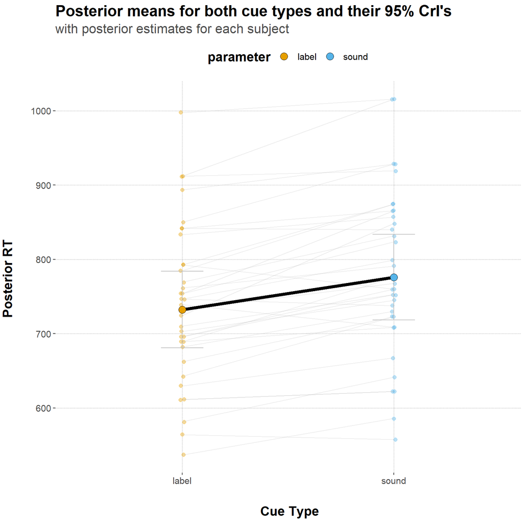

```r
# Extract the posteriors
posteriors <- hypo1_re %>%
  spread_draws(b_Intercept,
               b_cue_typesound) %>%
  # calculate posteriors for each individual level
  # added exp to retransform the values to ms
  mutate(label = exp(b_Intercept),
         sound = exp(b_Intercept + b_cue_typesound)) %>%
  select(label, sound) %>%
  gather(key = "parameter", value = "posterior") %>%
  group_by(parameter) %>%
  summarise(mean_posterior = mean(posterior),
            `95lowerCrI` = HDInterval::hdi(posterior, credMass = 0.95)[1],
            `95higherCrI` = HDInterval::hdi(posterior, credMass = 0.95)[2])



# extract the random intercepts for exemplars
random_intc_matrix <- ranef(hypo1_re)$subject_id[, , "Intercept"] %>%
  round(digits = 2)

# extract the by-exemplar random slopes for group
random_slope_matrix <- ranef(hypo1_re)$subject_id[, , "cue_typesound"] %>%
  round(digits = 2)

# random intercepts to dataframe
random_intc_df <- data.frame(subject_id = row.names(random_intc_matrix), random_intc_matrix) %>%
  select(subject_id, Estimate) %>%
  rename(rintercept = Estimate)

# combine with random slope matrix
random_slope_df <- data.frame(subject_id = row.names(random_slope_matrix), random_slope_matrix) %>%
  select(subject_id, Estimate) %>%
  rename(rslope = Estimate) %>%
  full_join(random_intc_df) %>%
  # add population parameters and group-specific parameters
  mutate(label_population = fixef(hypo1_re)[1],
         sound_population = fixef(hypo1_re)[1] + fixef(hypo1_re)[2],
         label = rintercept + label_population,
         sound = rintercept + rslope + sound_population) %>%
  select(subject_id, sound, label) %>%
  gather(parameter, mean_posterior, -subject_id)

# added exp to retransform the values to ms
random_slope_df$mean_posterior <- exp(random_slope_df$mean_posterior)

# combine with plot
ggplot(data = posteriors,
       aes(x = parameter, y = mean_posterior,
           color = parameter, fill = parameter)) +
   # add random estimates
  geom_point(data = random_slope_df,
             alpha = 0.4,
             size = 2,
             position = position_jitter(width = 0.01)
             ) +
  # add lines between random estimates
  geom_line(data = random_slope_df,
            aes(group = subject_id),
            color = "grey", alpha = 0.3) +
  # add population-level estimates
  geom_errorbar(aes(ymin = `95lowerCrI`, ymax = `95higherCrI`),
                width = 0.2, color = "grey") +
  geom_line(aes(group = 1), size = 2, color = "black") +
  geom_point(size = 4, pch = 21, color = "black") +
  labs(x = "\n Cue Type",
       y = "Posterior RT \n",
       title = "Posterior means for both cue types and their 95% CrI's",
       subtitle = "with posterior estimates for each subject")
```

As one can see, most lines slope upward just like the population estimate. However, they do so to different degrees. Moreover, one can also see that some subjects show the opposite patterns with downward sloping lines. Hence, it is very useful to account for these discrepancies between our subjects.

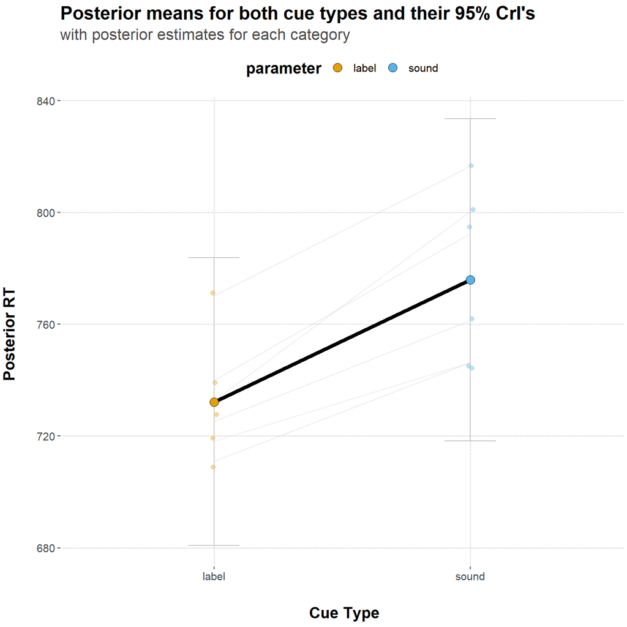

```r
# extract the random intercepts for exemplars
random_intc_matrix <- ranef(hypo1_max_re)$category[, , "Intercept"] %>%
  round(digits = 2)

# extract the by-exemplar random slopes for group
random_slope_matrix <- ranef(hypo1_max_re)$category[, , "cue_typesound"] %>%
  round(digits = 2)

# random intercepts to dataframe
random_intc_df <- data.frame(category = row.names(random_intc_matrix), random_intc_matrix) %>%
  select(category, Estimate) %>%
  rename(rintercept = Estimate)

# combine with random slope matrix
random_slope_df <- data.frame(category = row.names(random_slope_matrix), random_slope_matrix) %>%
  select(category, Estimate) %>%
  rename(rslope = Estimate) %>%
  full_join(random_intc_df) %>%
  # add population parameters and group-specific parameters
  mutate(label_population = fixef(hypo1_max_re)[1],
         sound_population = fixef(hypo1_max_re)[1] + fixef(hypo1_max_re)[2],
         label = rintercept + label_population,
         sound = rintercept + rslope + sound_population) %>%
  select(category, sound, label) %>%
  gather(parameter, mean_posterior, -category)

# added exp to retransform the values to ms
random_slope_df$mean_posterior <- exp(random_slope_df$mean_posterior)

# combine with plot
ggplot(data = posteriors,
       aes(x = parameter, y = mean_posterior,
           color = parameter, fill = parameter)) +
   # add random estimates
  geom_point(data = random_slope_df,
             alpha = 0.4,
             size = 2,
             position = position_jitter(width = 0.01)
             ) +
  # add lines between random estimates
  geom_line(data = random_slope_df,
            aes(group = category),
            color = "grey", alpha = 0.3) +
  # add population-level estimates
  geom_errorbar(aes(ymin = `95lowerCrI`, ymax = `95higherCrI`),
                width = 0.2, color = "grey") +
  geom_line(aes(group = 1), size = 2, color = "black") +
  geom_point(size = 4, pch = 21, color = "black") +
  labs(x = "\n Cue Type",
       y = "Posterior RT \n",
       title = "Posterior means for both cue types and their 95% CrI's",
       subtitle = "with posterior estimates for each category")
```

When looking at the different regression lines for each category from the max_re model we see that the random by category slopes can indeed be left out. The lines vary with respect to the intercept but not so much with respect to the population level slope.

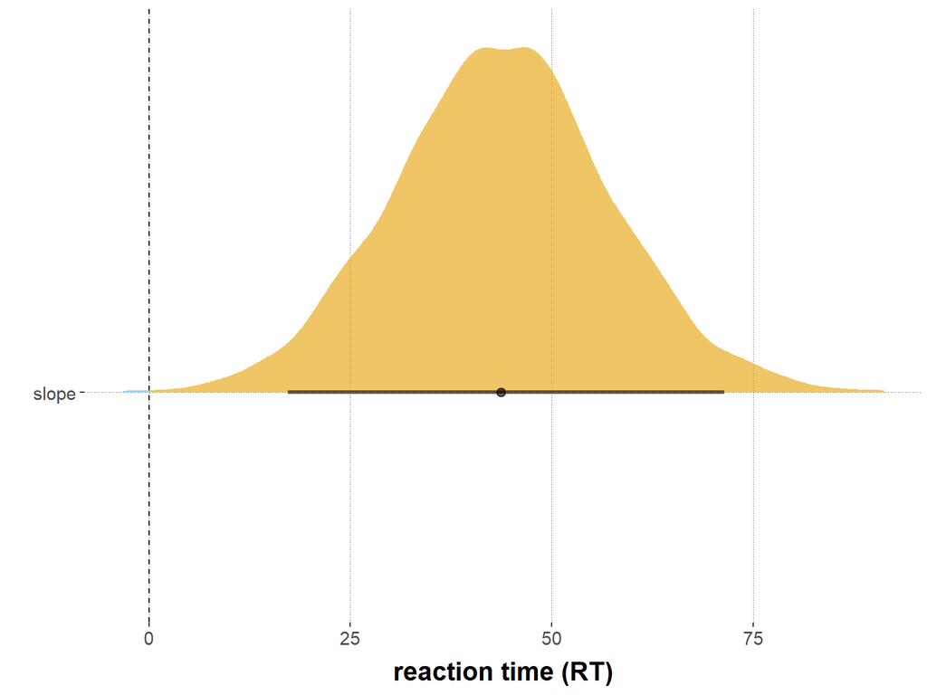

```r
# Extracting posterior samples from our model to plot a halfeyeh plot
posteriors2 <- hypo1_re %>%
  spread_draws(b_cue_typesound, b_Intercept) %>%
  select(b_cue_typesound, b_Intercept) %>%
  # in order to make our results intuitively understandable we retransformed our slope parameter back to ms
  mutate(slope = exp(b_Intercept+b_cue_typesound)-exp(b_Intercept)) %>%
  select(slope) %>%
  gather(key = "parameter", value = "posterior")

ggplot(posteriors2, aes(x = posterior, y = parameter)) +
  geom_halfeyeh(aes(fill = stat(x<0)), .width = 0.95, alpha = 0.6) +
  geom_segment(x= 0, xend = 0, y = Inf, yend = -Inf, lty = 'dashed') +
  labs(x = "reaction time (RT)",
       y = "") +
  theme(legend.position = "none")
```

When looking at the CrI for the population level slope coefficient `b_cue_typesound`, which gives us the change in reaction time when switching from the spoken labels to the environmental sounds, we see that 0 is excluded log_ms [0.02, 0.09] / ms [17.65, 71.58] –> the posterior CrI is reasonably far away from zero and only includes positive values Thus, given the data, the model and the priors, we can be certain that this coefficient is not zero and that there is in fact a positive relationship between RT and cue_type. This gives credence to our first hypothesis.

## Second Hypothesis

```r
# checking if random effects (intercept and slope) are in theory possible to apply to our second model
xtabs(~congruency+subject_id, data_hypothesis2)
```

```
##              subject_id
## congruency    1421 1422 1423 1425 1427 1430 1431 1432 1433 1434 1436 1468 1476
##   congruent     10   12   14   14   18   23   20   17   16   19   18   13   15
##   incongruent    9   14   19   14   16   12   12   16   16   15   13   15   15
##              subject_id
## congruency    1478 1479 1482 1483 1484 1486 1494 1495 1505 1515 1536 1562 1571
##   congruent     13   15   19   20   21   12   19   16   10   19   18   15   14
##   incongruent   21   16   12   11   14   16   14   17   20   13    8   18   13
##              subject_id
## congruency    1573 1575 1583 1603 1612 1630 1636 1639 1649
##   congruent     17   15   12    8   14   19   15   15   19
##   incongruent   13   16   17    7   16   11   21   12   15
```

```r
xtabs(~congruency+category, data_hypothesis2)
```

```
##              category
## congruency    bird car dog instrument phone typing
##   congruent     98  82  92         95    88     99
##   incongruent   87  68  99         92    84     77
```

Each subject and each category provides multiple data points for each level of congruency. Hence, it is in theory justified to use random by subjects / by category intercepts and slopes.

```r
# brm model without random effects
hypo2 <- brm(
  RT_log ~ congruency,
  # data
  data = data_hypothesis2,
  # seed
  seed = 1
)
```

```r
# brm model with random effects that are licensed by the data
# as 0 was included in the random by category slope and random by subject_id slope in the max_re model we just used the respective random intercepts here
hypo2_re <- brm(
  RT_log ~ congruency + (1 || subject_id) + (1 || category),
  # data
  data = data_hypothesis2,
  # seed
  seed = 1
)
```

```r
# brm model with rmaximal andom effects that are licensed by the data
hypo2_max_re <- brm(
  RT_log ~ congruency + (congruency || subject_id) + (congruency || category),
  # data
  data = data_hypothesis2,
  # seed
  seed = 1
)
```

### Model output and fit

```r
# checking the models output and fit
hypo2
```

```
##  Family: gaussian
##   Links: mu = identity; sigma = identity
## Formula: RT_log ~ congruency
##    Data: data_hypothesis2 (Number of observations: 1061)
## Samples: 4 chains, each with iter = 2000; warmup = 1000; thin = 1;
##          total post-warmup samples = 4000
##
## Population-Level Effects:
##                       Estimate Est.Error l-95% CI u-95% CI Rhat Bulk_ESS
## Intercept                 6.61      0.01     6.58     6.63 1.00     4551
## congruencyincongruent     0.08      0.02     0.04     0.12 1.00     4346
##                       Tail_ESS
## Intercept                 3270
## congruencyincongruent     2992
##
## Family Specific Parameters:
##       Estimate Est.Error l-95% CI u-95% CI Rhat Bulk_ESS Tail_ESS
## sigma     0.33      0.01     0.31     0.34 1.00     3705     2820
##
## Samples were drawn using sampling(NUTS). For each parameter, Bulk_ESS
## and Tail_ESS are effective sample size measures, and Rhat is the potential
## scale reduction factor on split chains (at convergence, Rhat = 1).
```

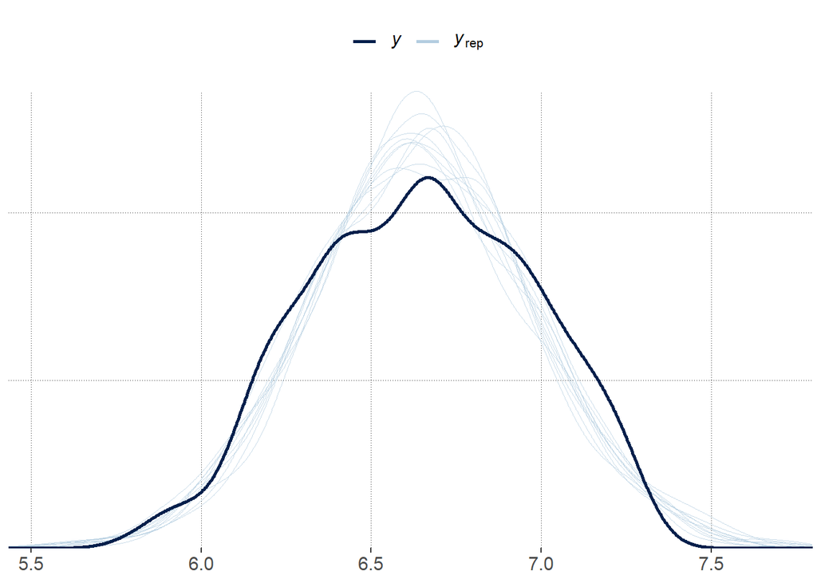

```r
pp_check(hypo2)
```

```r
# checking the models output and fit
print(hypo2_re, digits = 5)
```

```
##  Family: gaussian
##   Links: mu = identity; sigma = identity
## Formula: RT_log ~ congruency + (1 || subject_id) + (1 || category)
##    Data: data_hypothesis2 (Number of observations: 1061)
## Samples: 4 chains, each with iter = 2000; warmup = 1000; thin = 1;
##          total post-warmup samples = 4000
##
## Group-Level Effects:
## ~category (Number of levels: 6)
##               Estimate Est.Error l-95% CI u-95% CI    Rhat Bulk_ESS Tail_ESS
## sd(Intercept)  0.05765   0.03200  0.01972  0.13926 1.00265      907     1117
##
## ~subject_id (Number of levels: 35)
##               Estimate Est.Error l-95% CI u-95% CI    Rhat Bulk_ESS Tail_ESS
## sd(Intercept)  0.14887   0.02189  0.11219  0.19695 1.01559      679     1390
##
## Population-Level Effects:
##                       Estimate Est.Error l-95% CI u-95% CI    Rhat Bulk_ESS
## Intercept              6.61155   0.03880  6.53624  6.68985 1.00520      840
## congruencyincongruent  0.08817   0.01820  0.05271  0.12306 1.00095     4430
##                       Tail_ESS
## Intercept                 1303
## congruencyincongruent     3164
##
## Family Specific Parameters:
##       Estimate Est.Error l-95% CI u-95% CI    Rhat Bulk_ESS Tail_ESS
## sigma  0.29307   0.00664  0.28098  0.30642 1.00144     4522     2766
##
## Samples were drawn using sampling(NUTS). For each parameter, Bulk_ESS
## and Tail_ESS are effective sample size measures, and Rhat is the potential
## scale reduction factor on split chains (at convergence, Rhat = 1).
```

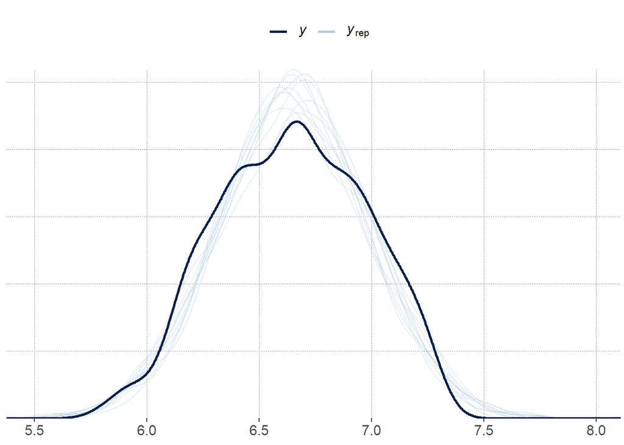

```r
pp_check(hypo2_re)
```

```r
# checking the models output and fit
hypo2_max_re
```

```
##  Family: gaussian
##   Links: mu = identity; sigma = identity
## Formula: RT_log ~ congruency + (congruency || subject_id) + (congruency || category)
##    Data: data_hypothesis2 (Number of observations: 1061)
## Samples: 4 chains, each with iter = 2000; warmup = 1000; thin = 1;
##          total post-warmup samples = 4000
##
## Group-Level Effects:
## ~category (Number of levels: 6)
##                           Estimate Est.Error l-95% CI u-95% CI Rhat Bulk_ESS
## sd(Intercept)                 0.06      0.03     0.01     0.14 1.00     1257
## sd(congruencyincongruent)     0.03      0.03     0.00     0.09 1.00     1844
##                           Tail_ESS
## sd(Intercept)                 1328
## sd(congruencyincongruent)     2274
##
## ~subject_id (Number of levels: 35)
##                           Estimate Est.Error l-95% CI u-95% CI Rhat Bulk_ESS
## sd(Intercept)                 0.15      0.02     0.11     0.20 1.00     1596
## sd(congruencyincongruent)     0.05      0.03     0.00     0.10 1.00      845
##                           Tail_ESS
## sd(Intercept)                 2676
## sd(congruencyincongruent)     1390
##
## Population-Level Effects:
##                       Estimate Est.Error l-95% CI u-95% CI Rhat Bulk_ESS
## Intercept                 6.61      0.04     6.53     6.69 1.00     1685
## congruencyincongruent     0.09      0.03     0.04     0.14 1.00     3815
##                       Tail_ESS
## Intercept                 2248
## congruencyincongruent     2320
##
## Family Specific Parameters:
##       Estimate Est.Error l-95% CI u-95% CI Rhat Bulk_ESS Tail_ESS
## sigma     0.29      0.01     0.28     0.31 1.00     6355     2978
##
## Samples were drawn using sampling(NUTS). For each parameter, Bulk_ESS
## and Tail_ESS are effective sample size measures, and Rhat is the potential
## scale reduction factor on split chains (at convergence, Rhat = 1).
```

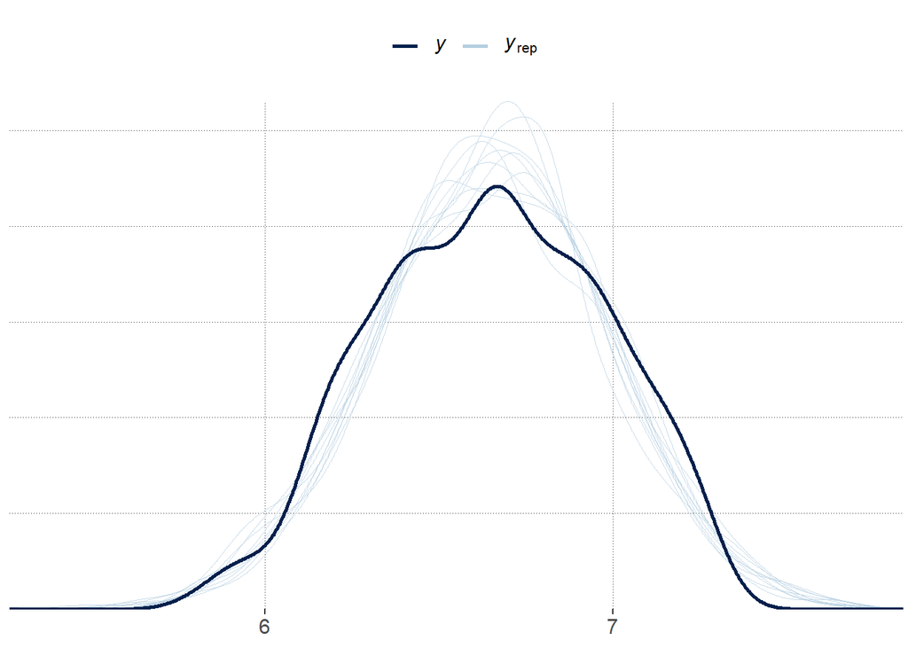

```r
pp_check(hypo2_max_re)
```

### Model comparison

```r
#Comparing both models using loo compare
model2 <- loo(hypo2)
model2_re <- loo(hypo2_re)
model2_max_re <- loo(hypo2_max_re)
loo_comp2 <- loo_compare(list(model2 = model2, model2_re = model2_re, model2_max_re = model2_max_re))
loo_comp2
```

```
##               elpd_diff se_diff
## model2_re       0.0       0.0
## model2_max_re  -0.7       1.3
## model2        -96.1      14.6
```

```r
#Using the z-test to obtain the p-value such we can judge significance of the loo compare results
1-pnorm(-loo_comp2[2,1], loo_comp2[2,2])
```

```
## [1] 0.7107351
```

```r
1-pnorm(-loo_comp1[3,1], loo_comp1[3,2])
```

```
## [1] 0
```

#### Evaluation of all models

```r
# in order to make our results intuitively understandable we retransformed our slope parameter back to ms
hypo2_re %>%
  spread_draws(b_congruencyincongruent, b_Intercept) %>%
  select(b_congruencyincongruent, b_Intercept) %>%
  mutate(slope = exp(b_Intercept+b_congruencyincongruent)-exp(b_Intercept)) %>%
  select(slope) %>%
  gather(key = "parameter", value = "posterior") %>%
  group_by(parameter) %>%
  summarise(mean_posterior = mean(posterior),
            `95lowerCrI` = HDInterval::hdi(posterior, credMass = 0.95)[1],
            `95higherCrI` = HDInterval::hdi(posterior, credMass = 0.95)[2])
```

```
## # A tibble: 1 x 4
##   parameter mean_posterior `95lowerCrI` `95higherCrI`
##   <chr>              <dbl>        <dbl>         <dbl>
## 1 slope               68.6         40.8          96.8
```

### Visual analysis

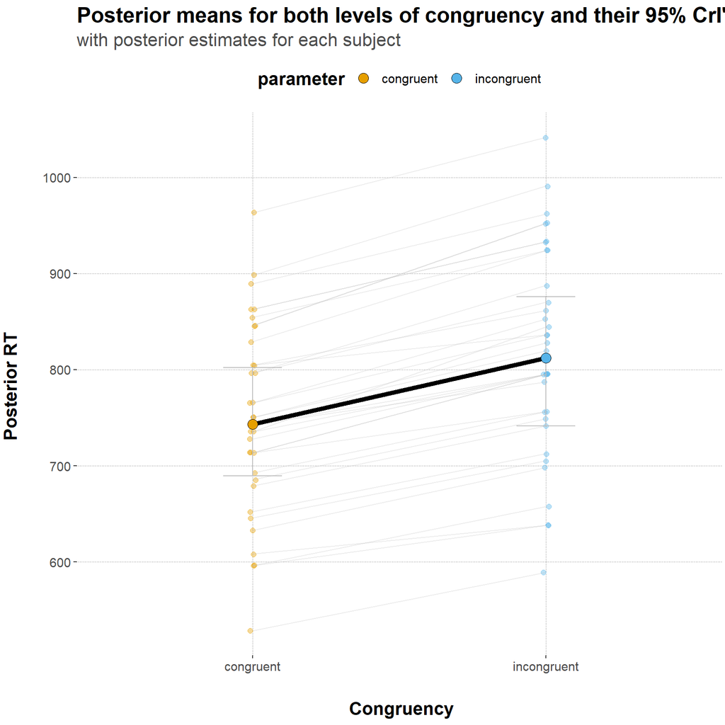

```r
# Extract the posteriors
posteriors3 <- hypo2_max_re %>%
  spread_draws(b_Intercept,
               b_congruencyincongruent) %>%
  # calculate posteriors for each individual level
  # added exp to retransform the values to ms
  mutate(congruent = exp(b_Intercept),
         incongruent = exp(b_Intercept + b_congruencyincongruent)) %>%
  select(congruent, incongruent) %>%
  gather(key = "parameter", value = "posterior") %>%
  group_by(parameter) %>%
  summarise(mean_posterior = mean(posterior),
            `95lowerCrI` = HDInterval::hdi(posterior, credMass = 0.95)[1],
            `95higherCrI` = HDInterval::hdi(posterior, credMass = 0.95)[2])



# extract the random intercepts for exemplars
random_intc_matrix <- ranef(hypo2_max_re)$subject_id[, , "Intercept"] %>%
  round(digits = 2)

# extract the by-exemplar random slopes for group
random_slope_matrix <- ranef(hypo2_max_re)$subject_id[, , "congruencyincongruent"] %>%
  round(digits = 2)

# random intercepts to dataframe
random_intc_df <- data.frame(subject_id = row.names(random_intc_matrix), random_intc_matrix) %>%
  select(subject_id, Estimate) %>%
  rename(rintercept = Estimate)

# combine with random slope matrix
random_slope_df <- data.frame(subject_id = row.names(random_slope_matrix), random_slope_matrix) %>%
  select(subject_id, Estimate) %>%
  rename(rslope = Estimate) %>%
  full_join(random_intc_df) %>%
  # add population parameters and group-specific parameters
  mutate(congruent_population = fixef(hypo2_max_re)[1],
         incongruent_population = fixef(hypo2_max_re)[1] + fixef(hypo2_max_re)[2],
         congruent = rintercept + congruent_population,
         incongruent = rintercept + rslope + incongruent_population) %>%
  select(subject_id, incongruent, congruent) %>%
  gather(parameter, mean_posterior, -subject_id)

# added exp to retransform the values to ms
random_slope_df$mean_posterior <- exp(random_slope_df$mean_posterior)

# combine with plot
ggplot(data = posteriors3,
       aes(x = parameter, y = mean_posterior,
           color = parameter, fill = parameter)) +
   # add random estimates
  geom_point(data = random_slope_df,
             alpha = 0.4,
             size = 2,
             position = position_jitter(width = 0.01)
             ) +
  # add lines between random estimates
  geom_line(data = random_slope_df,
            aes(group = subject_id),
            color = "grey", alpha = 0.3) +
  # add population-level estimates
  geom_errorbar(aes(ymin = `95lowerCrI`, ymax = `95higherCrI`),
                width = 0.2, color = "grey") +
  geom_line(aes(group = 1), size = 2, color = "black") +
  geom_point(size = 4, pch = 21, color = "black") +
  labs(x = "\n Congruency",
       y = "Posterior RT \n",
       title = "Posterior means for both levels of congruency and their 95% CrI's",
       subtitle = "with posterior estimates for each subject")
```